# Risk Factor Analysis

## Outcome Variable

**Outcome Variable:** wast_rec90d

## Predictor Variables

**Intervention Variable:** birthlen

**Adjustment Set:**

- arm
- sex
- W_mage
- meducyrs
- feducyrs
- hhwealth_quart
- vagbrth
- W_nrooms
- brthmon
- W_parity
- impfloor
- impsan
- safeh20
- delta_W_mage
- delta_meducyrs
- delta_feducyrs
- delta_hhwealth_quart
- delta_vagbrth
- delta_W_nrooms
- delta_brthmon
- delta_W_parity
- delta_impfloor
- delta_impsan
- delta_safeh20

## Stratifying Variables

The analysis was stratified on these variable(s):

- agecat
- studyid
- country

## Data Summary

| agecat | studyid | country | birthlen | wast_rec90d | n_cell | n |
| --- | --- | --- | --- | --- | --- | --- |
| 0-24 months | ki0047075b-MAL-ED | BANGLADESH | >=50 cm | 0 | 4 | 119 |
| 0-24 months | ki0047075b-MAL-ED | BANGLADESH | >=50 cm | 1 | 12 | 119 |
| 0-24 months | ki0047075b-MAL-ED | BANGLADESH | <48 cm | 0 | 25 | 119 |
| 0-24 months | ki0047075b-MAL-ED | BANGLADESH | <48 cm | 1 | 43 | 119 |
| 0-24 months | ki0047075b-MAL-ED | BANGLADESH | [48-50) cm | 0 | 15 | 119 |
| 0-24 months | ki0047075b-MAL-ED | BANGLADESH | [48-50) cm | 1 | 20 | 119 |
| 0-24 months | ki0047075b-MAL-ED | BRAZIL | >=50 cm | 0 | 0 | 22 |
| 0-24 months | ki0047075b-MAL-ED | BRAZIL | >=50 cm | 1 | 6 | 22 |
| 0-24 months | ki0047075b-MAL-ED | BRAZIL | <48 cm | 0 | 3 | 22 |
| 0-24 months | ki0047075b-MAL-ED | BRAZIL | <48 cm | 1 | 6 | 22 |
| 0-24 months | ki0047075b-MAL-ED | BRAZIL | [48-50) cm | 0 | 2 | 22 |
| 0-24 months | ki0047075b-MAL-ED | BRAZIL | [48-50) cm | 1 | 5 | 22 |
| 0-24 months | ki0047075b-MAL-ED | INDIA | >=50 cm | 0 | 3 | 144 |
| 0-24 months | ki0047075b-MAL-ED | INDIA | >=50 cm | 1 | 9 | 144 |
| 0-24 months | ki0047075b-MAL-ED | INDIA | <48 cm | 0 | 35 | 144 |
| 0-24 months | ki0047075b-MAL-ED | INDIA | <48 cm | 1 | 45 | 144 |
| 0-24 months | ki0047075b-MAL-ED | INDIA | [48-50) cm | 0 | 19 | 144 |
| 0-24 months | ki0047075b-MAL-ED | INDIA | [48-50) cm | 1 | 33 | 144 |
| 0-24 months | ki0047075b-MAL-ED | NEPAL | >=50 cm | 0 | 4 | 72 |
| 0-24 months | ki0047075b-MAL-ED | NEPAL | >=50 cm | 1 | 8 | 72 |
| 0-24 months | ki0047075b-MAL-ED | NEPAL | <48 cm | 0 | 8 | 72 |
| 0-24 months | ki0047075b-MAL-ED | NEPAL | <48 cm | 1 | 38 | 72 |
| 0-24 months | ki0047075b-MAL-ED | NEPAL | [48-50) cm | 0 | 1 | 72 |
| 0-24 months | ki0047075b-MAL-ED | NEPAL | [48-50) cm | 1 | 13 | 72 |
| 0-24 months | ki0047075b-MAL-ED | PERU | >=50 cm | 0 | 0 | 34 |
| 0-24 months | ki0047075b-MAL-ED | PERU | >=50 cm | 1 | 4 | 34 |
| 0-24 months | ki0047075b-MAL-ED | PERU | <48 cm | 0 | 5 | 34 |
| 0-24 months | ki0047075b-MAL-ED | PERU | <48 cm | 1 | 17 | 34 |
| 0-24 months | ki0047075b-MAL-ED | PERU | [48-50) cm | 0 | 1 | 34 |
| 0-24 months | ki0047075b-MAL-ED | PERU | [48-50) cm | 1 | 7 | 34 |

[output cut: 444 more lines]

The following strata were considered:

- agecat: 0-24 months, studyid: ki0047075b-MAL-ED, country: BANGLADESH
- agecat: 0-24 months, studyid: ki0047075b-MAL-ED, country: BRAZIL
- agecat: 0-24 months, studyid: ki0047075b-MAL-ED, country: INDIA
- agecat: 0-24 months, studyid: ki0047075b-MAL-ED, country: NEPAL
- agecat: 0-24 months, studyid: ki0047075b-MAL-ED, country: PERU
- agecat: 0-24 months, studyid: ki0047075b-MAL-ED, country: SOUTH AFRICA
- agecat: 0-24 months, studyid: ki0047075b-MAL-ED, country: TANZANIA, UNITED REPUBLIC OF
- agecat: 0-24 months, studyid: ki1000108-CMC-V-BCS-2002, country: INDIA
- agecat: 0-24 months, studyid: ki1000108-IRC, country: INDIA
- agecat: 0-24 months, studyid: ki1000109-EE, country: PAKISTAN
- agecat: 0-24 months, studyid: ki1000109-ResPak, country: PAKISTAN
- agecat: 0-24 months, studyid: ki1000304b-SAS-CompFeed, country: INDIA
- agecat: 0-24 months, studyid: ki1017093-NIH-Birth, country: BANGLADESH
- agecat: 0-24 months, studyid: ki1017093b-PROVIDE, country: BANGLADESH
- agecat: 0-24 months, studyid: ki1017093c-NIH-Crypto, country: BANGLADESH
- agecat: 0-24 months, studyid: ki1101329-Keneba, country: GAMBIA
- agecat: 0-24 months, studyid: ki1114097-CMIN, country: BANGLADESH
- agecat: 0-24 months, studyid: ki1114097-CMIN, country: BRAZIL
- agecat: 0-24 months, studyid: ki1114097-CMIN, country: GUINEA-BISSAU
- agecat: 0-24 months, studyid: ki1114097-CMIN, country: PERU
- agecat: 0-24 months, studyid: ki1119695-PROBIT, country: BELARUS
- agecat: 0-24 months, studyid: ki1126311-ZVITAMBO, country: ZIMBABWE
- agecat: 0-24 months, studyid: ki1135781-COHORTS, country: GUATEMALA
- agecat: 0-24 months, studyid: ki1135781-COHORTS, country: INDIA
- agecat: 0-24 months, studyid: ki1135781-COHORTS, country: PHILIPPINES
- agecat: 0-24 months, studyid: kiGH5241-JiVitA-3, country: BANGLADESH
- agecat: 0-24 months, studyid: kiGH5241-JiVitA-4, country: BANGLADESH
- agecat: 0-6 months, studyid: ki0047075b-MAL-ED, country: BANGLADESH
- agecat: 0-6 months, studyid: ki0047075b-MAL-ED, country: BRAZIL
- agecat: 0-6 months, studyid: ki0047075b-MAL-ED, country: INDIA
- agecat: 0-6 months, studyid: ki0047075b-MAL-ED, country: NEPAL
- agecat: 0-6 months, studyid: ki0047075b-MAL-ED, country: PERU
- agecat: 0-6 months, studyid: ki0047075b-MAL-ED, country: SOUTH AFRICA
- agecat: 0-6 months, studyid: ki0047075b-MAL-ED, country: TANZANIA, UNITED REPUBLIC OF
- agecat: 0-6 months, studyid: ki1000108-CMC-V-BCS-2002, country: INDIA
- agecat: 0-6 months, studyid: ki1000108-IRC, country: INDIA
- agecat: 0-6 months, studyid: ki1000109-EE, country: PAKISTAN
- agecat: 0-6 months, studyid: ki1000109-ResPak, country: PAKISTAN
- agecat: 0-6 months, studyid: ki1000304b-SAS-CompFeed, country: INDIA
- agecat: 0-6 months, studyid: ki1017093-NIH-Birth, country: BANGLADESH
- agecat: 0-6 months, studyid: ki1017093b-PROVIDE, country: BANGLADESH
- agecat: 0-6 months, studyid: ki1017093c-NIH-Crypto, country: BANGLADESH
- agecat: 0-6 months, studyid: ki1101329-Keneba, country: GAMBIA
- agecat: 0-6 months, studyid: ki1114097-CMIN, country: BANGLADESH
- agecat: 0-6 months, studyid: ki1114097-CMIN, country: BRAZIL
- agecat: 0-6 months, studyid: ki1114097-CMIN, country: GUINEA-BISSAU
- agecat: 0-6 months, studyid: ki1114097-CMIN, country: PERU
- agecat: 0-6 months, studyid: ki1119695-PROBIT, country: BELARUS
- agecat: 0-6 months, studyid: ki1126311-ZVITAMBO, country: ZIMBABWE
- agecat: 0-6 months, studyid: ki1135781-COHORTS, country: GUATEMALA
- agecat: 0-6 months, studyid: ki1135781-COHORTS, country: INDIA
- agecat: 0-6 months, studyid: ki1135781-COHORTS, country: PHILIPPINES
- agecat: 0-6 months, studyid: kiGH5241-JiVitA-3, country: BANGLADESH
- agecat: 0-6 months, studyid: kiGH5241-JiVitA-4, country: BANGLADESH
- agecat: 6-24 months, studyid: ki0047075b-MAL-ED, country: BANGLADESH
- agecat: 6-24 months, studyid: ki0047075b-MAL-ED, country: BRAZIL
- agecat: 6-24 months, studyid: ki0047075b-MAL-ED, country: INDIA
- agecat: 6-24 months, studyid: ki0047075b-MAL-ED, country: NEPAL
- agecat: 6-24 months, studyid: ki0047075b-MAL-ED, country: PERU
- agecat: 6-24 months, studyid: ki0047075b-MAL-ED, country: SOUTH AFRICA
- agecat: 6-24 months, studyid: ki0047075b-MAL-ED, country: TANZANIA, UNITED REPUBLIC OF
- agecat: 6-24 months, studyid: ki1000108-CMC-V-BCS-2002, country: INDIA
- agecat: 6-24 months, studyid: ki1000108-IRC, country: INDIA
- agecat: 6-24 months, studyid: ki1000109-EE, country: PAKISTAN
- agecat: 6-24 months, studyid: ki1000109-ResPak, country: PAKISTAN
- agecat: 6-24 months, studyid: ki1000304b-SAS-CompFeed, country: INDIA
- agecat: 6-24 months, studyid: ki1017093-NIH-Birth, country: BANGLADESH
- agecat: 6-24 months, studyid: ki1017093b-PROVIDE, country: BANGLADESH
- agecat: 6-24 months, studyid: ki1017093c-NIH-Crypto, country: BANGLADESH
- agecat: 6-24 months, studyid: ki1101329-Keneba, country: GAMBIA
- agecat: 6-24 months, studyid: ki1114097-CMIN, country: BRAZIL
- agecat: 6-24 months, studyid: ki1114097-CMIN, country: PERU
- agecat: 6-24 months, studyid: ki1119695-PROBIT, country: BELARUS
- agecat: 6-24 months, studyid: ki1126311-ZVITAMBO, country: ZIMBABWE
- agecat: 6-24 months, studyid: ki1135781-COHORTS, country: GUATEMALA
- agecat: 6-24 months, studyid: ki1135781-COHORTS, country: INDIA
- agecat: 6-24 months, studyid: ki1135781-COHORTS, country: PHILIPPINES
- agecat: 6-24 months, studyid: kiGH5241-JiVitA-3, country: BANGLADESH
- agecat: 6-24 months, studyid: kiGH5241-JiVitA-4, country: BANGLADESH

### Dropped Strata

Some strata were dropped due to rare outcomes:

- agecat: 0-24 months, studyid: ki0047075b-MAL-ED, country: BANGLADESH
- agecat: 0-24 months, studyid: ki0047075b-MAL-ED, country: BRAZIL
- agecat: 0-24 months, studyid: ki0047075b-MAL-ED, country: INDIA
- agecat: 0-24 months, studyid: ki0047075b-MAL-ED, country: NEPAL
- agecat: 0-24 months, studyid: ki0047075b-MAL-ED, country: PERU
- agecat: 0-24 months, studyid: ki0047075b-MAL-ED, country: SOUTH AFRICA
- agecat: 0-24 months, studyid: ki0047075b-MAL-ED, country: TANZANIA, UNITED REPUBLIC OF
- agecat: 0-24 months, studyid: ki1000108-CMC-V-BCS-2002, country: INDIA
- agecat: 0-24 months, studyid: ki1000109-ResPak, country: PAKISTAN
- agecat: 0-24 months, studyid: ki1114097-CMIN, country: BANGLADESH
- agecat: 0-24 months, studyid: ki1114097-CMIN, country: BRAZIL
- agecat: 0-24 months, studyid: ki1114097-CMIN, country: GUINEA-BISSAU
- agecat: 0-24 months, studyid: ki1114097-CMIN, country: PERU
- agecat: 0-6 months, studyid: ki0047075b-MAL-ED, country: BANGLADESH
- agecat: 0-6 months, studyid: ki0047075b-MAL-ED, country: BRAZIL
- agecat: 0-6 months, studyid: ki0047075b-MAL-ED, country: INDIA
- agecat: 0-6 months, studyid: ki0047075b-MAL-ED, country: NEPAL
- agecat: 0-6 months, studyid: ki0047075b-MAL-ED, country: PERU
- agecat: 0-6 months, studyid: ki0047075b-MAL-ED, country: SOUTH AFRICA
- agecat: 0-6 months, studyid: ki0047075b-MAL-ED, country: TANZANIA, UNITED REPUBLIC OF
- agecat: 0-6 months, studyid: ki1000108-CMC-V-BCS-2002, country: INDIA
- agecat: 0-6 months, studyid: ki1000109-EE, country: PAKISTAN
- agecat: 0-6 months, studyid: ki1000109-ResPak, country: PAKISTAN
- agecat: 0-6 months, studyid: ki1017093-NIH-Birth, country: BANGLADESH
- agecat: 0-6 months, studyid: ki1017093c-NIH-Crypto, country: BANGLADESH
- agecat: 0-6 months, studyid: ki1114097-CMIN, country: BANGLADESH
- agecat: 0-6 months, studyid: ki1114097-CMIN, country: BRAZIL
- agecat: 0-6 months, studyid: ki1114097-CMIN, country: GUINEA-BISSAU
- agecat: 0-6 months, studyid: ki1114097-CMIN, country: PERU
- agecat: 6-24 months, studyid: ki0047075b-MAL-ED, country: BANGLADESH
- agecat: 6-24 months, studyid: ki0047075b-MAL-ED, country: BRAZIL
- agecat: 6-24 months, studyid: ki0047075b-MAL-ED, country: INDIA
- agecat: 6-24 months, studyid: ki0047075b-MAL-ED, country: NEPAL
- agecat: 6-24 months, studyid: ki0047075b-MAL-ED, country: PERU
- agecat: 6-24 months, studyid: ki0047075b-MAL-ED, country: SOUTH AFRICA
- agecat: 6-24 months, studyid: ki0047075b-MAL-ED, country: TANZANIA, UNITED REPUBLIC OF
- agecat: 6-24 months, studyid: ki1000108-CMC-V-BCS-2002, country: INDIA
- agecat: 6-24 months, studyid: ki1000109-EE, country: PAKISTAN
- agecat: 6-24 months, studyid: ki1000109-ResPak, country: PAKISTAN
- agecat: 6-24 months, studyid: ki1017093-NIH-Birth, country: BANGLADESH
- agecat: 6-24 months, studyid: ki1017093b-PROVIDE, country: BANGLADESH
- agecat: 6-24 months, studyid: ki1017093c-NIH-Crypto, country: BANGLADESH
- agecat: 6-24 months, studyid: ki1114097-CMIN, country: BRAZIL
- agecat: 6-24 months, studyid: ki1114097-CMIN, country: PERU
- agecat: 6-24 months, studyid: ki1119695-PROBIT, country: BELARUS
- agecat: 6-24 months, studyid: ki1135781-COHORTS, country: GUATEMALA
- agecat: 6-24 months, studyid: ki1135781-COHORTS, country: INDIA
- agecat: 6-24 months, studyid: kiGH5241-JiVitA-3, country: BANGLADESH

## Methods Detail

We’re interested in the causal parameters $E[Y_a]$ for all values of $a \in \mathcal{A}$. These parameters represent the mean outcome if, possibly contrary to fact, we intervened to set all units to have $A=a$. Under the randomization and positivity assumptions, these are identified by the statistical parameters $\psi_a=E_W[E_{Y|A,W}(Y|A=a,W)]$. In addition, we’re interested in the mean of $Y$, $E[Y]$ under no intervention (the observed mean). We will estimate these parameters by using SuperLearner to fit the relevant likelihood factors – $E_{Y|A,W}(Y|A=a,W)$ and $p(A=a|W)$, and then updating our likelihood fit using a joint TMLE.

For unadjusted analyses ($W=\{\}$), initial likelihoods were estimated using Lrnr_glm to estimate the simple $E(Y|A)$ and Lrnr_mean to estimate $p(A)$. For adjusted analyses, a small library containing Lrnr_glmnet, Lrnr_xgboost, and Lrnr_mean was used.

Having estimated these parameters, we will then use the delta method to estimate relative risks and attributable risks relative to a prespecified baseline level of $A$.

# Results Detail

## Results Plots

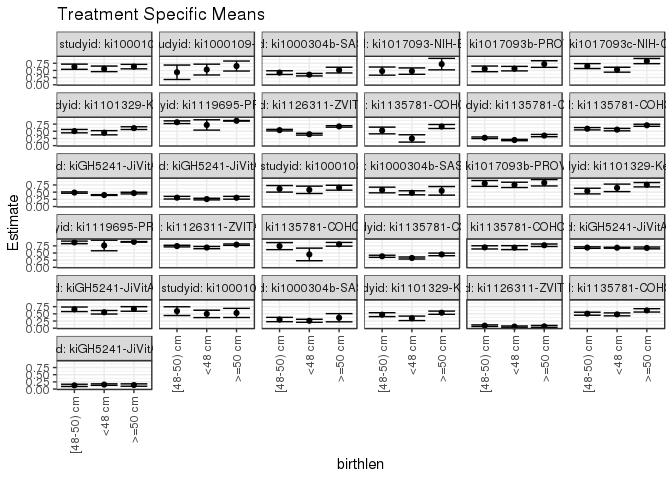

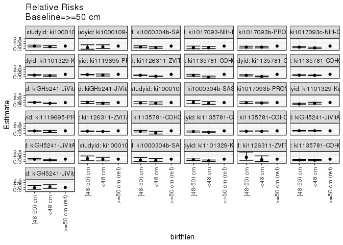

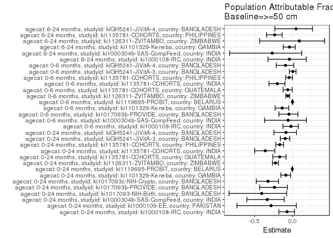

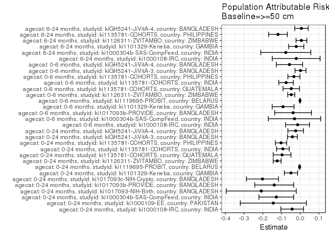

## Results Table

### Parameter: TSM

| agecat | studyid | country | intervention_level | baseline_level | estimate | ci_lower | ci_upper |
| --- | --- | --- | --- | --- | --- | --- | --- |
| 0-24 months | ki1000108-IRC | INDIA | >=50 cm | NA | 0.6323663 | 0.5542941 | 0.7104384 |
| 0-24 months | ki1000108-IRC | INDIA | <48 cm | NA | 0.5545515 | 0.4576473 | 0.6514556 |
| 0-24 months | ki1000108-IRC | INDIA | [48-50) cm | NA | 0.6281880 | 0.5378178 | 0.7185582 |
| 0-24 months | ki1000109-EE | PAKISTAN | >=50 cm | NA | 0.6519786 | 0.4776149 | 0.8263424 |
| 0-24 months | ki1000109-EE | PAKISTAN | <48 cm | NA | 0.5292491 | 0.3414032 | 0.7170949 |
| 0-24 months | ki1000109-EE | PAKISTAN | [48-50) cm | NA | 0.4348104 | 0.1835393 | 0.6860815 |
| 0-24 months | ki1000304b-SAS-CompFeed | INDIA | >=50 cm | NA | 0.5111016 | 0.4112190 | 0.6109841 |
| 0-24 months | ki1000304b-SAS-CompFeed | INDIA | <48 cm | NA | 0.3508238 | 0.3075522 | 0.3940953 |
| 0-24 months | ki1000304b-SAS-CompFeed | INDIA | [48-50) cm | NA | 0.4234006 | 0.3587413 | 0.4880600 |
| 0-24 months | ki1017093-NIH-Birth | BANGLADESH | >=50 cm | NA | 0.7200000 | 0.5200875 | 0.9199125 |
| 0-24 months | ki1017093-NIH-Birth | BANGLADESH | <48 cm | NA | 0.4756098 | 0.3649515 | 0.5862680 |
| 0-24 months | ki1017093-NIH-Birth | BANGLADESH | [48-50) cm | NA | 0.4761905 | 0.3342656 | 0.6181153 |
| 0-24 months | ki1017093b-PROVIDE | BANGLADESH | >=50 cm | NA | 0.7218958 | 0.6068577 | 0.8369340 |
| 0-24 months | ki1017093b-PROVIDE | BANGLADESH | <48 cm | NA | 0.5618420 | 0.4831752 | 0.6405088 |
| 0-24 months | ki1017093b-PROVIDE | BANGLADESH | [48-50) cm | NA | 0.5541363 | 0.4552455 | 0.6530270 |
| 0-24 months | ki1017093c-NIH-Crypto | BANGLADESH | >=50 cm | NA | 0.8256856 | 0.7351412 | 0.9162300 |
| 0-24 months | ki1017093c-NIH-Crypto | BANGLADESH | <48 cm | NA | 0.5237984 | 0.4381786 | 0.6094182 |
| 0-24 months | ki1017093c-NIH-Crypto | BANGLADESH | [48-50) cm | NA | 0.6509555 | 0.5657937 | 0.7361173 |
| 0-24 months | ki1101329-Keneba | GAMBIA | >=50 cm | NA | 0.6090355 | 0.5615365 | 0.6565345 |
| 0-24 months | ki1101329-Keneba | GAMBIA | <48 cm | NA | 0.4495266 | 0.3766375 | 0.5224158 |
| 0-24 months | ki1101329-Keneba | GAMBIA | [48-50) cm | NA | 0.5053157 | 0.4458056 | 0.5648258 |
| 0-24 months | ki1119695-PROBIT | BELARUS | >=50 cm | NA | 0.8648064 | 0.8544839 | 0.8751288 |
| 0-24 months | ki1119695-PROBIT | BELARUS | <48 cm | NA | 0.7200000 | 0.5401187 | 0.8998813 |
| 0-24 months | ki1119695-PROBIT | BELARUS | [48-50) cm | NA | 0.8152610 | 0.7681659 | 0.8623562 |
| 0-24 months | ki1126311-ZVITAMBO | ZIMBABWE | >=50 cm | NA | 0.6691314 | 0.6433911 | 0.6948718 |
| 0-24 months | ki1126311-ZVITAMBO | ZIMBABWE | <48 cm | NA | 0.3970165 | 0.3661226 | 0.4279104 |
| 0-24 months | ki1126311-ZVITAMBO | ZIMBABWE | [48-50) cm | NA | 0.5397650 | 0.5132391 | 0.5662910 |
| 0-24 months | ki1135781-COHORTS | GUATEMALA | >=50 cm | NA | 0.6664214 | 0.5969565 | 0.7358863 |
| 0-24 months | ki1135781-COHORTS | GUATEMALA | <48 cm | NA | 0.2504180 | 0.1221265 | 0.3787094 |
| 0-24 months | ki1135781-COHORTS | GUATEMALA | [48-50) cm | NA | 0.5274943 | 0.4105459 | 0.6444428 |

[output cut: 63 more lines]

### Parameter: E(Y)

| agecat | studyid | country | intervention_level | baseline_level | estimate | ci_lower | ci_upper |
| --- | --- | --- | --- | --- | --- | --- | --- |
| 0-24 months | ki1000108-IRC | INDIA | NA | NA | 0.5891473 | 0.5364145 | 0.6418800 |
| 0-24 months | ki1000109-EE | PAKISTAN | NA | NA | 0.5079365 | 0.3724516 | 0.6434214 |
| 0-24 months | ki1000304b-SAS-CompFeed | INDIA | NA | NA | 0.3831891 | 0.3479331 | 0.4184451 |
| 0-24 months | ki1017093-NIH-Birth | BANGLADESH | NA | NA | 0.5117647 | 0.4302715 | 0.5932579 |
| 0-24 months | ki1017093b-PROVIDE | BANGLADESH | NA | NA | 0.5830619 | 0.5262762 | 0.6398476 |
| 0-24 months | ki1017093c-NIH-Crypto | BANGLADESH | NA | NA | 0.6237942 | 0.5698223 | 0.6777662 |
| 0-24 months | ki1101329-Keneba | GAMBIA | NA | NA | 0.5593036 | 0.5241177 | 0.5944895 |
| 0-24 months | ki1119695-PROBIT | BELARUS | NA | NA | 0.8612051 | 0.8511051 | 0.8713052 |
| 0-24 months | ki1126311-ZVITAMBO | ZIMBABWE | NA | NA | 0.5459916 | 0.5294878 | 0.5624953 |
| 0-24 months | ki1135781-COHORTS | GUATEMALA | NA | NA | 0.5694915 | 0.5120418 | 0.6269413 |
| 0-24 months | ki1135781-COHORTS | INDIA | NA | NA | 0.2579095 | 0.2406335 | 0.2751855 |
| 0-24 months | ki1135781-COHORTS | PHILIPPINES | NA | NA | 0.6067616 | 0.5822457 | 0.6312775 |
| 0-24 months | kiGH5241-JiVitA-3 | BANGLADESH | NA | NA | 0.4249094 | 0.4136873 | 0.4361315 |
| 0-24 months | kiGH5241-JiVitA-4 | BANGLADESH | NA | NA | 0.2796610 | 0.2580570 | 0.3012650 |
| 0-6 months | ki1000108-IRC | INDIA | NA | NA | 0.6398305 | 0.5770134 | 0.7026476 |
| 0-6 months | ki1000304b-SAS-CompFeed | INDIA | NA | NA | 0.5147059 | 0.4610948 | 0.5683169 |
| 0-6 months | ki1017093b-PROVIDE | BANGLADESH | NA | NA | 0.7880435 | 0.7295878 | 0.8464992 |
| 0-6 months | ki1101329-Keneba | GAMBIA | NA | NA | 0.6666667 | 0.6089363 | 0.7243970 |
| 0-6 months | ki1119695-PROBIT | BELARUS | NA | NA | 0.8855266 | 0.8758983 | 0.8951550 |
| 0-6 months | ki1126311-ZVITAMBO | ZIMBABWE | NA | NA | 0.7430390 | 0.7259692 | 0.7601088 |
| 0-6 months | ki1135781-COHORTS | GUATEMALA | NA | NA | 0.7547170 | 0.6968087 | 0.8126253 |
| 0-6 months | ki1135781-COHORTS | INDIA | NA | NA | 0.3750728 | 0.3521661 | 0.3979795 |
| 0-6 months | ki1135781-COHORTS | PHILIPPINES | NA | NA | 0.7363515 | 0.7047428 | 0.7679603 |
| 0-6 months | kiGH5241-JiVitA-3 | BANGLADESH | NA | NA | 0.6779443 | 0.6645427 | 0.6913460 |
| 0-6 months | kiGH5241-JiVitA-4 | BANGLADESH | NA | NA | 0.6130952 | 0.5705324 | 0.6556580 |
| 6-24 months | ki1000108-IRC | INDIA | NA | NA | 0.5099338 | 0.4248374 | 0.5950302 |
| 6-24 months | ki1000304b-SAS-CompFeed | INDIA | NA | NA | 0.2878465 | 0.2457514 | 0.3299415 |
| 6-24 months | ki1101329-Keneba | GAMBIA | NA | NA | 0.5180723 | 0.4773341 | 0.5588105 |
| 6-24 months | ki1126311-ZVITAMBO | ZIMBABWE | NA | NA | 0.0701249 | 0.0547060 | 0.0855437 |
| 6-24 months | ki1135781-COHORTS | PHILIPPINES | NA | NA | 0.5026738 | 0.4688037 | 0.5365439 |
| 6-24 months | kiGH5241-JiVitA-4 | BANGLADESH | NA | NA | 0.1469194 | 0.1276367 | 0.1662021 |

### Parameter: RR

| agecat | studyid | country | intervention_level | baseline_level | estimate | ci_lower | ci_upper |
| --- | --- | --- | --- | --- | --- | --- | --- |
| 0-24 months | ki1000108-IRC | INDIA | >=50 cm | >=50 cm | 1.0000000 | 1.0000000 | 1.0000000 |
| 0-24 months | ki1000108-IRC | INDIA | <48 cm | >=50 cm | 0.8769467 | 0.7084495 | 1.0855190 |
| 0-24 months | ki1000108-IRC | INDIA | [48-50) cm | >=50 cm | 0.9933926 | 0.8217676 | 1.2008613 |
| 0-24 months | ki1000109-EE | PAKISTAN | >=50 cm | >=50 cm | 1.0000000 | 1.0000000 | 1.0000000 |
| 0-24 months | ki1000109-EE | PAKISTAN | <48 cm | >=50 cm | 0.8117583 | 0.5214174 | 1.2637697 |
| 0-24 months | ki1000109-EE | PAKISTAN | [48-50) cm | >=50 cm | 0.6669090 | 0.3512790 | 1.2661378 |
| 0-24 months | ki1000304b-SAS-CompFeed | INDIA | >=50 cm | >=50 cm | 1.0000000 | 1.0000000 | 1.0000000 |
| 0-24 months | ki1000304b-SAS-CompFeed | INDIA | <48 cm | >=50 cm | 0.6864071 | 0.5451996 | 0.8641876 |
| 0-24 months | ki1000304b-SAS-CompFeed | INDIA | [48-50) cm | >=50 cm | 0.8284080 | 0.6467158 | 1.0611459 |
| 0-24 months | ki1017093-NIH-Birth | BANGLADESH | >=50 cm | >=50 cm | 1.0000000 | 1.0000000 | 1.0000000 |
| 0-24 months | ki1017093-NIH-Birth | BANGLADESH | <48 cm | >=50 cm | 0.6605691 | 0.4598630 | 0.9488729 |
| 0-24 months | ki1017093-NIH-Birth | BANGLADESH | [48-50) cm | >=50 cm | 0.6613757 | 0.4401309 | 0.9938357 |
| 0-24 months | ki1017093b-PROVIDE | BANGLADESH | >=50 cm | >=50 cm | 1.0000000 | 1.0000000 | 1.0000000 |
| 0-24 months | ki1017093b-PROVIDE | BANGLADESH | <48 cm | >=50 cm | 0.7782868 | 0.6295486 | 0.9621662 |
| 0-24 months | ki1017093b-PROVIDE | BANGLADESH | [48-50) cm | >=50 cm | 0.7676125 | 0.6041780 | 0.9752571 |
| 0-24 months | ki1017093c-NIH-Crypto | BANGLADESH | >=50 cm | >=50 cm | 1.0000000 | 1.0000000 | 1.0000000 |
| 0-24 months | ki1017093c-NIH-Crypto | BANGLADESH | <48 cm | >=50 cm | 0.6343800 | 0.5205446 | 0.7731095 |
| 0-24 months | ki1017093c-NIH-Crypto | BANGLADESH | [48-50) cm | >=50 cm | 0.7883818 | 0.6647338 | 0.9350297 |
| 0-24 months | ki1101329-Keneba | GAMBIA | >=50 cm | >=50 cm | 1.0000000 | 1.0000000 | 1.0000000 |
| 0-24 months | ki1101329-Keneba | GAMBIA | <48 cm | >=50 cm | 0.7380960 | 0.6166670 | 0.8834358 |
| 0-24 months | ki1101329-Keneba | GAMBIA | [48-50) cm | >=50 cm | 0.8296983 | 0.7205734 | 0.9553491 |
| 0-24 months | ki1119695-PROBIT | BELARUS | >=50 cm | >=50 cm | 1.0000000 | 1.0000000 | 1.0000000 |
| 0-24 months | ki1119695-PROBIT | BELARUS | <48 cm | >=50 cm | 0.8325563 | 0.6483177 | 1.0691518 |
| 0-24 months | ki1119695-PROBIT | BELARUS | [48-50) cm | >=50 cm | 0.9427094 | 0.8887094 | 0.9999905 |
| 0-24 months | ki1126311-ZVITAMBO | ZIMBABWE | >=50 cm | >=50 cm | 1.0000000 | 1.0000000 | 1.0000000 |
| 0-24 months | ki1126311-ZVITAMBO | ZIMBABWE | <48 cm | >=50 cm | 0.5933311 | 0.5440460 | 0.6470809 |
| 0-24 months | ki1126311-ZVITAMBO | ZIMBABWE | [48-50) cm | >=50 cm | 0.8066652 | 0.7579533 | 0.8585077 |
| 0-24 months | ki1135781-COHORTS | GUATEMALA | >=50 cm | >=50 cm | 1.0000000 | 1.0000000 | 1.0000000 |
| 0-24 months | ki1135781-COHORTS | GUATEMALA | <48 cm | >=50 cm | 0.3757652 | 0.2228064 | 0.6337317 |
| 0-24 months | ki1135781-COHORTS | GUATEMALA | [48-50) cm | >=50 cm | 0.7915327 | 0.6194707 | 1.0113862 |

[output cut: 63 more lines]

### Parameter: PAR

| agecat | studyid | country | intervention_level | baseline_level | estimate | ci_lower | ci_upper |
| --- | --- | --- | --- | --- | --- | --- | --- |
| 0-24 months | ki1000108-IRC | INDIA | >=50 cm | NA | -0.0432190 | -0.1037602 | 0.0173223 |
| 0-24 months | ki1000109-EE | PAKISTAN | >=50 cm | NA | -0.1440421 | -0.3205745 | 0.0324903 |
| 0-24 months | ki1000304b-SAS-CompFeed | INDIA | >=50 cm | NA | -0.1279125 | -0.2208403 | -0.0349846 |
| 0-24 months | ki1017093-NIH-Birth | BANGLADESH | >=50 cm | NA | -0.2082353 | -0.3952402 | -0.0212304 |
| 0-24 months | ki1017093b-PROVIDE | BANGLADESH | >=50 cm | NA | -0.1388340 | -0.2429513 | -0.0347166 |
| 0-24 months | ki1017093c-NIH-Crypto | BANGLADESH | >=50 cm | NA | -0.2018914 | -0.2872525 | -0.1165303 |
| 0-24 months | ki1101329-Keneba | GAMBIA | >=50 cm | NA | -0.0497319 | -0.0851250 | -0.0143387 |
| 0-24 months | ki1119695-PROBIT | BELARUS | >=50 cm | NA | -0.0036012 | -0.0065370 | -0.0006654 |
| 0-24 months | ki1126311-ZVITAMBO | ZIMBABWE | >=50 cm | NA | -0.1231399 | -0.1440340 | -0.1022457 |
| 0-24 months | ki1135781-COHORTS | GUATEMALA | >=50 cm | NA | -0.0969299 | -0.1443587 | -0.0495011 |
| 0-24 months | ki1135781-COHORTS | INDIA | >=50 cm | NA | -0.0927573 | -0.1268405 | -0.0586740 |
| 0-24 months | ki1135781-COHORTS | PHILIPPINES | >=50 cm | NA | -0.1026415 | -0.1328076 | -0.0724754 |
| 0-24 months | kiGH5241-JiVitA-3 | BANGLADESH | >=50 cm | NA | -0.0417505 | -0.0681366 | -0.0153643 |
| 0-24 months | kiGH5241-JiVitA-4 | BANGLADESH | >=50 cm | NA | -0.0244782 | -0.0660002 | 0.0170439 |
| 0-6 months | ki1000108-IRC | INDIA | >=50 cm | NA | -0.0141592 | -0.0782385 | 0.0499200 |
| 0-6 months | ki1000304b-SAS-CompFeed | INDIA | >=50 cm | NA | -0.0306301 | -0.1705684 | 0.1093083 |
| 0-6 months | ki1017093b-PROVIDE | BANGLADESH | >=50 cm | NA | -0.0380435 | -0.1362822 | 0.0601952 |
| 0-6 months | ki1101329-Keneba | GAMBIA | >=50 cm | NA | -0.0916474 | -0.1500433 | -0.0332516 |
| 0-6 months | ki1119695-PROBIT | BELARUS | >=50 cm | NA | -0.0015381 | -0.0041179 | 0.0010418 |
| 0-6 months | ki1126311-ZVITAMBO | ZIMBABWE | >=50 cm | NA | -0.0479838 | -0.0669874 | -0.0289802 |
| 0-6 months | ki1135781-COHORTS | GUATEMALA | >=50 cm | NA | -0.0480999 | -0.0918402 | -0.0043596 |
| 0-6 months | ki1135781-COHORTS | INDIA | >=50 cm | NA | -0.0756621 | -0.1146110 | -0.0367132 |
| 0-6 months | ki1135781-COHORTS | PHILIPPINES | >=50 cm | NA | -0.0338838 | -0.0660756 | -0.0016920 |
| 0-6 months | kiGH5241-JiVitA-3 | BANGLADESH | >=50 cm | NA | 0.0013120 | -0.0280998 | 0.0307238 |
| 0-6 months | kiGH5241-JiVitA-4 | BANGLADESH | >=50 cm | NA | -0.0576171 | -0.1276451 | 0.0124109 |
| 6-24 months | ki1000108-IRC | INDIA | >=50 cm | NA | -0.0216525 | -0.1493209 | 0.1060159 |
| 6-24 months | ki1000304b-SAS-CompFeed | INDIA | >=50 cm | NA | -0.0772715 | -0.2109245 | 0.0563815 |
| 6-24 months | ki1101329-Keneba | GAMBIA | >=50 cm | NA | -0.0215957 | -0.0622105 | 0.0190191 |
| 6-24 months | ki1126311-ZVITAMBO | ZIMBABWE | >=50 cm | NA | 0.0061980 | -0.0227405 | 0.0351364 |
| 6-24 months | ki1135781-COHORTS | PHILIPPINES | >=50 cm | NA | -0.1187565 | -0.1689423 | -0.0685708 |
| 6-24 months | kiGH5241-JiVitA-4 | BANGLADESH | >=50 cm | NA | 0.0065686 | -0.0293629 | 0.0425000 |

### Parameter: PAF

| agecat | studyid | country | intervention_level | baseline_level | estimate | ci_lower | ci_upper |
| --- | --- | --- | --- | --- | --- | --- | --- |
| 0-24 months | ki1000108-IRC | INDIA | >=50 cm | NA | -0.0733585 | -0.1818253 | 0.0251533 |
| 0-24 months | ki1000109-EE | PAKISTAN | >=50 cm | NA | -0.2835829 | -0.7313251 | 0.0483676 |
| 0-24 months | ki1000304b-SAS-CompFeed | INDIA | >=50 cm | NA | -0.3338103 | -0.6015452 | -0.1108333 |
| 0-24 months | ki1017093-NIH-Birth | BANGLADESH | >=50 cm | NA | -0.4068966 | -0.8360307 | -0.0780636 |
| 0-24 months | ki1017093b-PROVIDE | BANGLADESH | >=50 cm | NA | -0.2381119 | -0.4337971 | -0.0691338 |
| 0-24 months | ki1017093c-NIH-Crypto | BANGLADESH | >=50 cm | NA | -0.3236507 | -0.4774645 | -0.1858499 |
| 0-24 months | ki1101329-Keneba | GAMBIA | >=50 cm | NA | -0.0889175 | -0.1548888 | -0.0267147 |
| 0-24 months | ki1119695-PROBIT | BELARUS | >=50 cm | NA | -0.0041816 | -0.0076001 | -0.0007747 |
| 0-24 months | ki1126311-ZVITAMBO | ZIMBABWE | >=50 cm | NA | -0.2255344 | -0.2654914 | -0.1868389 |
| 0-24 months | ki1135781-COHORTS | GUATEMALA | >=50 cm | NA | -0.1702042 | -0.2607801 | -0.0861354 |
| 0-24 months | ki1135781-COHORTS | INDIA | >=50 cm | NA | -0.3596505 | -0.4983921 | -0.2337555 |
| 0-24 months | ki1135781-COHORTS | PHILIPPINES | >=50 cm | NA | -0.1691628 | -0.2212364 | -0.1193097 |
| 0-24 months | kiGH5241-JiVitA-3 | BANGLADESH | >=50 cm | NA | -0.0982574 | -0.1622860 | -0.0377560 |
| 0-24 months | kiGH5241-JiVitA-4 | BANGLADESH | >=50 cm | NA | -0.0875279 | -0.2461140 | 0.0508758 |
| 0-6 months | ki1000108-IRC | INDIA | >=50 cm | NA | -0.0221297 | -0.1276234 | 0.0734947 |
| 0-6 months | ki1000304b-SAS-CompFeed | INDIA | >=50 cm | NA | -0.0595098 | -0.3695021 | 0.1803145 |
| 0-6 months | ki1017093b-PROVIDE | BANGLADESH | >=50 cm | NA | -0.0482759 | -0.1809211 | 0.0694702 |
| 0-6 months | ki1101329-Keneba | GAMBIA | >=50 cm | NA | -0.1374711 | -0.2310682 | -0.0509901 |
| 0-6 months | ki1119695-PROBIT | BELARUS | >=50 cm | NA | -0.0017369 | -0.0046554 | 0.0011731 |
| 0-6 months | ki1126311-ZVITAMBO | ZIMBABWE | >=50 cm | NA | -0.0645778 | -0.0906800 | -0.0391002 |
| 0-6 months | ki1135781-COHORTS | GUATEMALA | >=50 cm | NA | -0.0637324 | -0.1245591 | -0.0061958 |
| 0-6 months | ki1135781-COHORTS | INDIA | >=50 cm | NA | -0.2017265 | -0.3110260 | -0.1015392 |
| 0-6 months | ki1135781-COHORTS | PHILIPPINES | >=50 cm | NA | -0.0460158 | -0.0909083 | -0.0029706 |
| 0-6 months | kiGH5241-JiVitA-3 | BANGLADESH | >=50 cm | NA | 0.0019353 | -0.0424035 | 0.0443881 |
| 0-6 months | kiGH5241-JiVitA-4 | BANGLADESH | >=50 cm | NA | -0.0939774 | -0.2150089 | 0.0149978 |
| 6-24 months | ki1000108-IRC | INDIA | >=50 cm | NA | -0.0424614 | -0.3248314 | 0.1797253 |
| 6-24 months | ki1000304b-SAS-CompFeed | INDIA | >=50 cm | NA | -0.2684468 | -0.8278649 | 0.1197614 |
| 6-24 months | ki1101329-Keneba | GAMBIA | >=50 cm | NA | -0.0416847 | -0.1233708 | 0.0340615 |
| 6-24 months | ki1126311-ZVITAMBO | ZIMBABWE | >=50 cm | NA | 0.0883847 | -0.4328943 | 0.4200252 |
| 6-24 months | ki1135781-COHORTS | PHILIPPINES | >=50 cm | NA | -0.2362497 | -0.3431216 | -0.1378815 |
| 6-24 months | kiGH5241-JiVitA-4 | BANGLADESH | >=50 cm | NA | 0.0447085 | -0.2341560 | 0.2605621 |